# 2.5. Exploratory data analysis

```r
library(janitor)
library(tidyverse)
library(lubridate)
library(ggplot2)

raw_beds <- read_csv("data/beds_by_nhs_board_of_treatment_and_specialty.csv")
```

```r
wranged_beds_no_gj <- raw_beds %>%
  clean_names() %>%
  mutate(q = str_sub(quarter, -2)) %>%
  # Change to date format
  mutate(quarter = yq(quarter)) %>%
  # rename the columns above
  mutate(date = quarter,
         quarter = q) %>%
  # Change Heath Board names to read better
  mutate(hb = if_else(hb %in% "S08000015", "Ayrshire & Arran",
                      if_else(hb %in% "S08000016", "Borders",
                      if_else(hb %in% "S08000017", "Dumfries & Galloway",
                      if_else(hb %in% "S08000019", "Forth Valley",
                      if_else(hb %in% "S08000020", "Grampian",
                      if_else(hb %in% "S08000022", "Highland",
                      if_else(hb %in% "S08000024", "Lothian",
                      if_else(hb %in% "S08000025", "Orkney",
                      if_else(hb %in% "S08000026", "Shetland",
                      if_else(hb %in% "S08000028", "Western Isles",
                      if_else(hb %in% "S08000029", "Fife",
                      if_else(hb %in% "S08000030", "Tayside",
                      if_else(hb %in% "S08000031", "Greater Glasgow & Clyde",
                      if_else(hb %in% "S08000032", "Lanarkshire",
                      if_else(hb %in% "S92000003", "Scotland", NA_character_)
                      ))))))))))))))) %>%
  # take out location names to take out duplicate
  filter(location_qf == "d") %>%

  # Take out of cleaning script and add when pulling in shiny

  # take out Golden Jubilee
  filter(hb != is.na(hb)) %>%
  # take out unused columns
  # take out location to remove duplicate
  select(date, quarter, hb, specialty_name, all_staffed_beds,
         total_occupied_beds, average_available_staffed_beds,
         average_occupied_beds, percentage_occupancy)

wranged_beds_no_gj
```

| date | quarter | hb | specialty_name | all_staffed_beds | total_occupied_beds | average_available_staffed_beds | average_occupied_beds | percentage_occupancy |
| --- | --- | --- | --- | --- | --- | --- | --- | --- |
| 2016-04-01 | Q2 | Ayrshire & Arran | Accident & Emergency | 396 | 252 | 4.351648e+00 | 2.769231e+00 | 63.6363636 |
| 2016-07-01 | Q3 | Ayrshire & Arran | Accident & Emergency | 345 | 249 | 3.750000e+00 | 2.706522e+00 | 72.1739130 |
| 2016-10-01 | Q4 | Ayrshire & Arran | Accident & Emergency | 323 | 200 | 3.510870e+00 | 2.173913e+00 | 61.9195046 |
| 2017-01-01 | Q1 | Ayrshire & Arran | Accident & Emergency | 373 | 269 | 4.144444e+00 | 2.988889e+00 | 72.1179625 |
| 2017-04-01 | Q2 | Ayrshire & Arran | Accident & Emergency | 404 | 404 | 4.439560e+00 | 4.439560e+00 | 100.0000000 |
| 2017-07-01 | Q3 | Ayrshire & Arran | Accident & Emergency | 388 | 388 | 4.217391e+00 | 4.217391e+00 | 100.0000000 |
| 2017-10-01 | Q4 | Ayrshire & Arran | Accident & Emergency | 346 | 346 | 3.760870e+00 | 3.760870e+00 | 100.0000000 |
| 2018-01-01 | Q1 | Ayrshire & Arran | Accident & Emergency | 216 | 216 | 2.400000e+00 | 2.400000e+00 | 100.0000000 |
| 2018-04-01 | Q2 | Ayrshire & Arran | Accident & Emergency | 254 | 254 | 2.791209e+00 | 2.791209e+00 | 100.0000000 |
| 2018-07-01 | Q3 | Ayrshire & Arran | Accident & Emergency | 220 | 220 | 2.391304e+00 | 2.391304e+00 | 100.0000000 |

[output cut: 990 more lines]

```r
unique(wranged_beds_no_gj$hb)
```

```
 [1] "Ayrshire & Arran"        "Borders"                 "Dumfries & Galloway"     "Fife"
 [5] "Forth Valley"            "Grampian"                "Greater Glasgow & Clyde" "Highland"
 [9] "Lanarkshire"             "Lothian"                 "Orkney"                  "Shetland"
[13] "Tayside"                 "Western Isles"           "Scotland"
```

### KPI: Capacity – what is happening to the number of beds over the period? Perhaps think about the specialities these are if there has been specific variation?

Shows the percentage occupancy per Specialty grouping

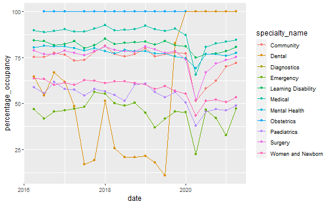

```r
wranged_beds_no_gj %>%
  filter(str_detect(specialty_name, " Grouping"),
         specialty_name != "Other Grouping",
         hb == "Scotland") %>%
  mutate(specialty_name = str_sub(specialty_name, start = 1, end = -9)) %>%
  ggplot(aes(x = date, y = percentage_occupancy, col = specialty_name)) +
  geom_point() +
  geom_line()
```

Obstetrics and Dental look odd as they have 100% occupancy some of the time, some show seasonal peaks.

Can change the `head()` in the chunk below to filter down the specialty. For shiny can filter by the highest occupancy or the specialty_name Have removed Obstetrics and Dental just to make clearer

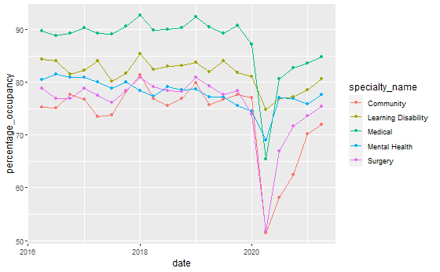

```r
bigest_occupancy <- wranged_beds_no_gj %>%
  filter(str_detect(specialty_name, " Grouping"),
         specialty_name != "Other Grouping",
         specialty_name != "Obstetrics Grouping",
         specialty_name != "Dental Grouping",
         hb == "Scotland") %>%
  group_by(specialty_name) %>%
  summarise(count = sum(percentage_occupancy)) %>%
  arrange(desc(count)) %>%
  # change head to
  head(5)

wranged_beds_no_gj %>%
  filter(specialty_name %in% c(bigest_occupancy$specialty_name)) %>%
  filter(str_detect(specialty_name, " Grouping"),
         specialty_name != "Other Grouping",
         hb == "Scotland") %>%
  mutate(specialty_name = str_sub(specialty_name, start = 1, end = -9)) %>%
  ggplot(aes(x = date, y = percentage_occupancy, col = specialty_name)) +
  geom_point() +
  geom_line()
```

This shows the regions

Can use for shiny changing the specialty_name.

Can add try to add a label to show what the highest number is

shows remote areas don’t need/uses some services so have belive have less can over lay the number total_occupied_beds at high point to give scale

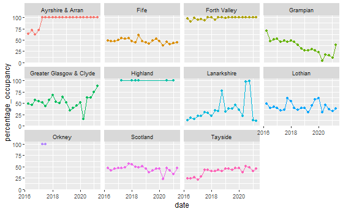

```r
wranged_beds_no_gj %>%
  filter(str_detect(specialty_name, " Grouping"),
         specialty_name != "Other Grouping",
         specialty_name == "Emergency Grouping") %>%
  mutate(specialty_name = str_sub(specialty_name, start = 1, end = -9)) %>%
  ggplot(aes(x = date, y = percentage_occupancy, col = hb)) +
  geom_point() +
  geom_line() +
  facet_wrap(~ hb) +
  theme(legend.position="none")
```

## seasonal trends for staffed beds in the top 3 specialty

Have taken the top 3 to show for ease. For shiny can filter by the highest occupancy or the specialty_name

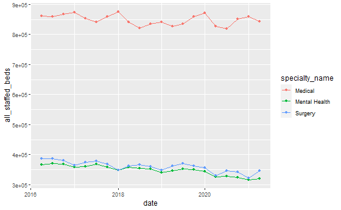

```r
bigest_specialty <- wranged_beds_no_gj %>%
  filter(str_detect(specialty_name, " Grouping"),
         specialty_name != "Other Grouping",
         hb == "Scotland") %>%
  group_by(specialty_name) %>%
  summarise(count = sum(all_staffed_beds)) %>%
  arrange(desc(count)) %>%
  head(3)


wranged_beds_no_gj %>%
  filter(specialty_name %in% c(bigest_specialty$specialty_name)) %>%
  filter(str_detect(specialty_name, " Grouping"),
         specialty_name != "Other Grouping",
         hb == "Scotland") %>%
  mutate(specialty_name = str_sub(specialty_name, start = 1, end = -9)) %>%
  ggplot(aes(x = date, y = all_staffed_beds, col = specialty_name)) +
  geom_point() +
  geom_line()
```

These two are more general shorts of the bed occupancy over Scotland. Can do a tab for both of them togeter

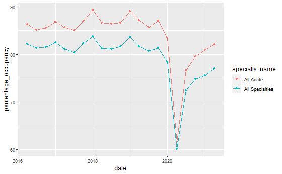

```r
wranged_beds_no_gj %>%
  filter(specialty_name %in% c("All Acute", "All Specialties"),
         hb %in% "Scotland") %>%
  ggplot(aes(x = date, y = percentage_occupancy, col = specialty_name)) +
  geom_point() +
  geom_line()
```

```r
wranged_beds_no_gj %>%
  filter(specialty_name %in% c("All Acute", "All Specialties"),
         hb %in% "Scotland") %>%
  ggplot(aes(x = date, y = average_occupied_beds, col = specialty_name)) +
  # geom_col(position = "dodge")
  geom_point() +
  geom_line()
```

[output not shown]

Shows the regions brake down Glasgow is the hub for most types of beds

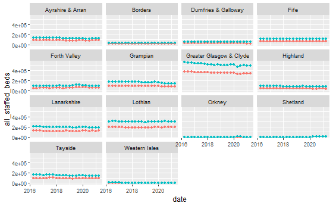

```r
wranged_beds_no_gj %>%
  filter(specialty_name %in% c("All Acute", "All Specialties"),
         hb != "Scotland") %>%
  ggplot(aes(x = date, y = all_staffed_beds, col = specialty_name)) +
  geom_point() +
  geom_line() +
  facet_wrap(~ hb) +
  theme(legend.position="none")
```

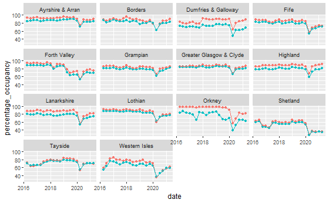

```r
wranged_beds_no_gj %>%
  filter(specialty_name %in% c("All Acute", "All Specialties"),
         hb != "Scotland") %>%
  ggplot(aes(x = date, y = percentage_occupancy, col = specialty_name)) +
  geom_point() +
  geom_line() +
  facet_wrap(~ hb) +
  theme(legend.position="none")
```

Can use this in shiny just filter it down by specialty